# Brinda Murulidhara HW4

Descriptive Statistics

Brinda Murulidhara  
2022-01-10

## Read in a dataset

I have chosen the Emergency - 911 calls dataset from Kaggle (https://www.kaggle.com/mchirico/montcoalert/version/32) for my final project. The dataset contains emergency 911 calls in Montgomery County, Pennsylvania from 2015 to 2020. Below is the code snippet to read and preview the data.

```r
library(dplyr)
emergency_calls_data <- read.csv("911.csv")
head(emergency_calls_data)
```

```
       lat       lng
1 40.29788 -75.58129
2 40.25806 -75.26468
3 40.12118 -75.35198
4 40.11615 -75.34351
5 40.25149 -75.60335
6 40.25347 -75.28324
                                                                                 desc
1           REINDEER CT & DEAD END;  NEW HANOVER; Station 332; 2015-12-10 @ 17:10:52;
2 BRIAR PATH & WHITEMARSH LN;  HATFIELD TOWNSHIP; Station 345; 2015-12-10 @ 17:29:21;
3                          HAWS AVE; NORRISTOWN; 2015-12-10 @ 14:39:21-Station:STA27;
4               AIRY ST & SWEDE ST;  NORRISTOWN; Station 308A; 2015-12-10 @ 16:47:36;
5    CHERRYWOOD CT & DEAD END;  LOWER POTTSGROVE; Station 329; 2015-12-10 @ 16:56:52;
6               CANNON AVE & W 9TH ST;  LANSDALE; Station 345; 2015-12-10 @ 15:39:04;
    zip                   title           timeStamp               twp
1 19525  EMS: BACK PAINS/INJURY 2015-12-10 17:10:52       NEW HANOVER
2 19446 EMS: DIABETIC EMERGENCY 2015-12-10 17:29:21 HATFIELD TOWNSHIP
3 19401     Fire: GAS-ODOR/LEAK 2015-12-10 14:39:21        NORRISTOWN
4 19401  EMS: CARDIAC EMERGENCY 2015-12-10 16:47:36        NORRISTOWN
5    NA          EMS: DIZZINESS 2015-12-10 16:56:52  LOWER POTTSGROVE
6 19446        EMS: HEAD INJURY 2015-12-10 15:39:04          LANSDALE
                        addr e
1     REINDEER CT & DEAD END 1
2 BRIAR PATH & WHITEMARSH LN 1
3                   HAWS AVE 1
4         AIRY ST & SWEDE ST 1
5   CHERRYWOOD CT & DEAD END 1
6      CANNON AVE & W 9TH ST 1
```

## Descriptive statistics

### Mean

Below are the means of latitude and longitude columns.

```r
summarise(emergency_calls_data, mean_latitude=mean(lat), mean_longitude=mean(lng))
```

```
  mean_latitude mean_longitude
1      40.15816       -75.3001
```

### Median

Below are the medians of latitude and longitude columns.

```r
summarise(emergency_calls_data, median_latitude=median(lat), median_longitude=median(lng))
```

```
  median_latitude median_longitude
1        40.14393        -75.30514
```

### Standard Deviation

Below are the standard deviations of latitude and longitude columns.

```r
summarise(emergency_calls_data, sd_latitude=sd(lat), sd_longitude=sd(lng))
```

```
  sd_latitude sd_longitude
1   0.2206414     1.672884
```

### Frequencies

Below are the frequencies of zipcodes (zip), emergency sub categories (title) and townships (twp).

```r
emergency_calls_data %>%
  count(zip)
```

```
      zip     n
1    1104     1
2    3103     2
3    3366     1
4    7081     1
5    7203     1
6    7726     1
7    8033     1
8    8065     1
9    8077     1
10   8361     4
11   8502     1
12   8628     3
13   8832     4
14  15090     1
```

[output cut: 191 more lines]

```r
emergency_calls_data %>%
  count(title)
```

```
                                   title      n
1                   EMS: ABDOMINAL PAINS   9005
2                    EMS: ACTIVE SHOOTER      3
3                 EMS: ALLERGIC REACTION   2878
4             EMS: ALTERED MENTAL STATUS  10088
5                        EMS: AMPUTATION     99
6                       EMS: ANIMAL BITE    583
7                    EMS: APPLIANCE FIRE     46
8                     EMS: ARMED SUBJECT      2
9                    EMS: ASSAULT VICTIM   4199
10                EMS: BACK PAINS/INJURY   4880
11               EMS: BARRICADED SUBJECT      2
12                EMS: BOMB DEVICE FOUND     10
13                      EMS: BOMB THREAT      2
14                    EMS: BUILDING FIRE   1323
```

[output cut: 134 more lines]

```r
emergency_calls_data %>%
  count(twp)
```

```
                 twp     n
1                      293
2           ABINGTON 39947
3             AMBLER  4454
4       BERKS COUNTY  1930
5         BRIDGEPORT  3695
6         BRYN ATHYN  1254
7       BUCKS COUNTY  1982
8         CHELTENHAM 30574
9     CHESTER COUNTY  7362
10      COLLEGEVILLE  2916
11      CONSHOHOCKEN  5655
12   DELAWARE COUNTY  1802
13          DOUGLASS  5550
14   EAST GREENVILLE  1316
```

[output cut: 55 more lines]

### Median latitude and longitude grouped by township

```r
emergency_calls_data %>%
  group_by(twp) %>%
  summarise(median_latitude=median(lat), median_longitude=median(lng))
```

```
# A tibble: 69 x 3
   twp              median_latitude median_longitude
   <chr>                      <dbl>            <dbl>
 1 ""                          40.2            -75.4
 2 "ABINGTON"                  40.1            -75.1
 3 "AMBLER"                    40.2            -75.2
 4 "BERKS COUNTY"              40.3            -75.6
 5 "BRIDGEPORT"                40.1            -75.3
 6 "BRYN ATHYN"                40.1            -75.1
 7 "BUCKS COUNTY"              40.2            -75.3
 8 "CHELTENHAM"                40.1            -75.1
 9 "CHESTER COUNTY"            40.2            -75.5
10 "COLLEGEVILLE"              40.2            -75.5
# ... with 59 more rows
```

### Univariate visualisation

#### Explanation

- Below is a plot of emergency subcategory (title) vs frequency of occurrence.
- This visualization helps us understand what kind of emergencies occur more frequently in Montgomery County. The emergency response team can make better preparations with this knowledge.
- We can conclude that vehicle accidents contribute the most to emergency calls in Montgomery County.

#### Limitations

- This visualization does not aid us in finding the distribution of emergency calls across townships. This is an important piece of information in making preparations for emergencies as some townships may get larger number of calls related to vehicle accidents while others may get more calls regarding stabbing and shooting.
- The number of emergency sub categories is large and the distinction between every one of those may be unclear to a naive viewer. It might be good to have a high level view of the emergency categories (E.g. EMS, Traffic, Fire) first and then drill down to the sub categories.
- I would include township variable and broad emergency categories (E.g. EMS, Traffic, Fire) in further visualizations to improve my project.

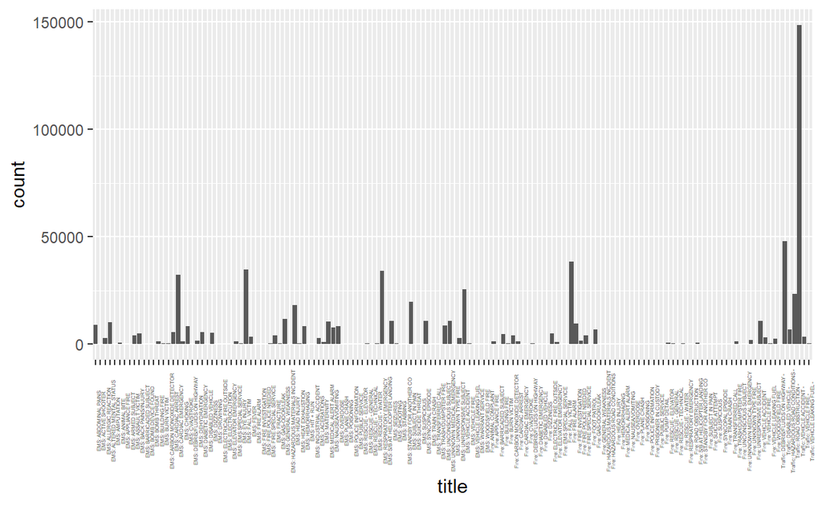

```r
library(ggplot2)
ggplot(emergency_calls_data, aes(x = title)) +
        geom_bar() +
        theme(axis.text.x=element_text(angle=90, size = 3))
```

### Bivariate Visualisation

#### Explanation

- Below is a plot of township (twp) vs frequency of occurrence grouped by emergency subcategory (title) for a sample of 50 rows.
- This visualization helps us understand what kind of emergencies occur more frequently in every township in Montgomery County. It also helps us compare the number of emergencies that occur across townships. The emergency response team can focus its efforts more on townships that have higher counts of emergencies.
- We can conclude that Lower Merion has the highest number of emergencies from the sample.

#### Limitations

- This visualization does not consider the entire dataset as it’s built only on a sample of rows. This may not give us a complete representation of the entire dataset.
- This visualization does not aid in comparing the trends in emergency calls across years or months.
- The number of emergency sub categories is large and the distinction between every one of those may be unclear to a naive viewer. It might be good to have a high level view of the emergency categories (E.g. EMS, Traffic, Fire) first and then drill down to the sub categories.
- I would include broad emergency categories (E.g. EMS, Traffic, Fire) and timestamps(year, month etc.) in further visualizations to improve my project. I would also see if it’s possible to group multiple geographically close counties into regions to avoid overwhelming a naive viewer with tens of counties in one visualization.

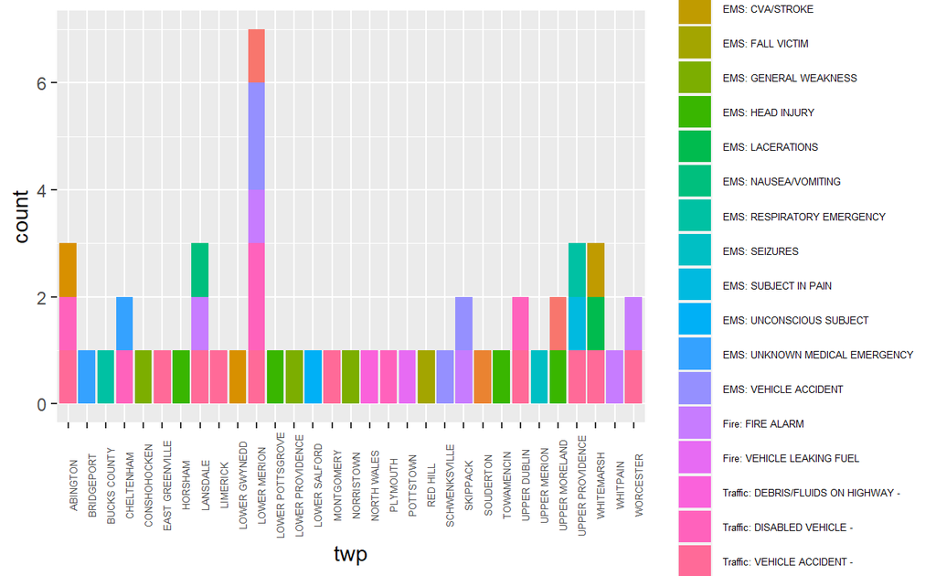

```r
set.seed(1)
emergency_calls_data[sample(nrow(emergency_calls_data), 50), ] %>%
ggplot(aes(x = twp,
           fill = title)) +
  geom_bar(position = "stack") +
  theme(axis.text.x=element_text(angle=90, size = 5), legend.text=element_text(size=5))
```